# AREC 570: Presentation

November 22, 2019

## Intro

Presentation is an essential part of the research process - for yourself and others

Attention is scarce - use it effectively

Present early and often - it forces you to refine your ideas and solicit feedback from others

- Early presentation: feedback on idea and directions of investigation
- Mid: conference and or seminar to test ideas and results; identify where questions remain
- Final (job talk): advertising polished piece of work

Go to other talks - learn by watching (and doing)

## Structure

The structure and organization of a talk is important (just like in a paper)

Problem

Contributions/Literature

Definitions and data

Results

Conclusions

## Problem

What is the problem to be analyzed?

Why should we care about resolving the issues?

What should we expect to learn?

Answers depend on the audience - don’t assume too much

Don’t dwell on this too long

State research question (explicitly and remember to deliver)

## Contribution

Brief overview of the approach

Preview the results

State contributions in the context of the most relevant literature - you can add to lit review at the end

Try to mention work of people in the audience (must in job talks)

Are the main contributions positive, normative, or methodological?

External validity - how much can you generalize?

How does your work connect beyond the specific context or topic?

## Methods and Data

Describe conceptual framework - enough detail to know what you are doing but not boring

Walk the audience through the intuition - maybe a simple version of the model is warranted (Varian)

Use figures and images to motivate intuition

Describe data and how you compile it; briefly mention any significant modifications

## Results

Remind audience of hypotheses and set them up to expect the result

Avoid long derivations (they can read the appendix)

Tables should focus on key results or highlight them in a readable table

Again, use figures when possible

## Example

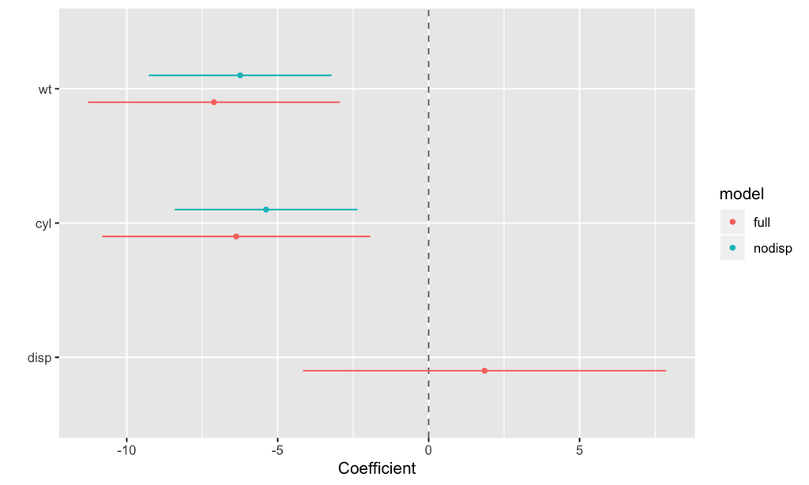

## Conclusion

Show the audience what they should have learned from the paper

Memorable takeaway message (advertisement)

Implications for future work

## Presentation

Determine your presentation style and own it

Dress appropriately and comfortably

Speak clearly and not too monotone

Try to maintain good energy to keep people engaged

Teaching is good practice - you can tell when you’re losing the audience

## Crowd Control

You are the boss of the talk and are responsible for keeping the talk moving

Answer questions if you know the answer; otherwise, say that you’ll come back to it or follow up with the person afterwards. I think you need to deliver on this promise to return to something.

Economics departments are notorious for being hostile presentation environments - ours is not

Forms of the heckler:

- Impatient: push you to get to the point quickly
- Stubborn: has strong opinions about a modeling choice and won’t let it go
- Axe-grinder: has some issue that they love to bring up and talk about

Easy to lose control of the crowd to herd mentality

## Software

Latex: beamer (signalling)

Rmarkdown: can integrate existing R analysis; html slides

Powerpoint: good for quick or image heavy presentations; non-econ audience - avoid gratuitous animation

Google slides

Prezi

## Tables and Figures

## Motivation

Your goal is to communicate your argument

Visual aides can efficiently communicate information

Make those visuals attractive and informative

Tufte principles

## Types of Graphics

What is the objective of the chart? Comparison, Trend, Composition

- scatter/points
- bar, area,

## Chart Components

Labels - help orient the viewer; don’t clutter

Scales - define the range of the data; honesty

Graphical elements - lines or bars that summarize information

## Schwabish Principles

*Show the data*: read the graphics to understand the story - make sure the data is clear

*Reduce clutter*: unnecessary ink on in the graphic that doesn’t convey information (e.g., heavy gridlines, unnecessary ticks and labels, [unnecessary 3D](http://image.slidesharecdn.com/infographics1-150422093618-conversion-gate02/95/infographics-the-good-and-the-bad-7-638.jpg?cb=1429875854))

- Avoid pie [charts](https://timoelliott.com/blog/wp-content/uploads/2013/01/bar-vs-pie.jpg)

*Integrate text into the graphics*: contain enough information to stand alone; integrate legends into the graphics when possible

## Color

Colors evoke emotion and may have a natural relation to values

- green: go, life, health, good, clean
- red: hot, bad
- blue: cool, water, clean

When possible, use colors that also work in grayscale: [viridis](https://i.stack.imgur.com/PLfsn.png)

Color blindness [test](https://images.ctfassets.net/u4vv676b8z52/6tpwrD6xE7eAVT48WiRO8G/9284182cda7c0bb02cd9cdae212c532c/color_blind_eye_exam.png)

## Examples

Default R graphics

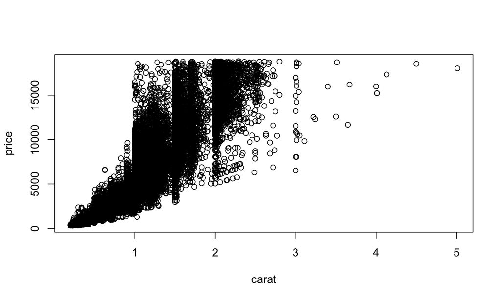

## ggplot

ggplot2 graphics

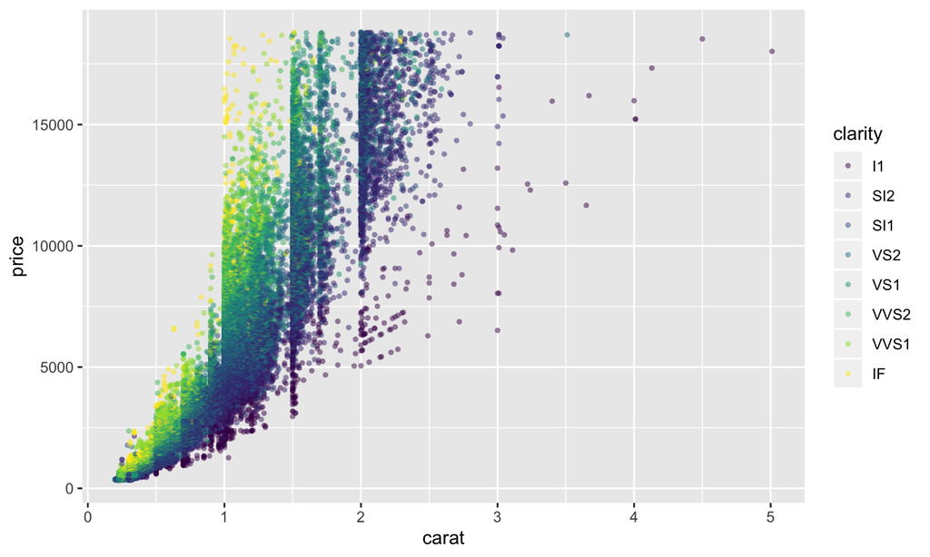

## ggplot: densities

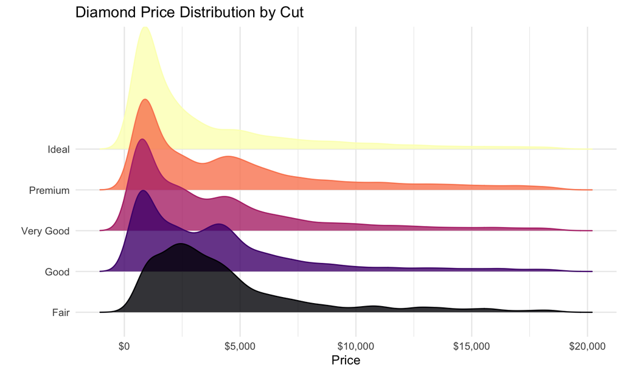

## ggplot: maps

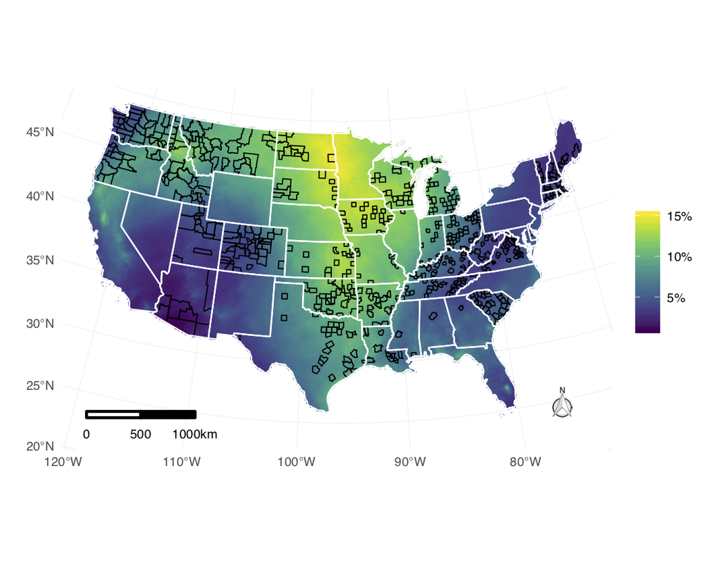

## facebook map

[figure not shown]

## Other images

[figure not shown]

## Other images: Influe-venn-za

[figure not shown]

## Other images: solar

[figure not shown]

## Other images: solar 2

[figure not shown]